# Zastosowanie wybranych metod porządkowania liniowego do oceny jakości życia w powiatach województwa łódzkiego

# Wstęp

Jakoś życia jest pojęciem obejmującym szereg czynników społecznych jak i gospodarczych a badania tego typu są dość popularne.Głownym celem tego typu analiz jest określenie (w tym przypadku) powiatu ktory oferuje najlespze warunki do edukacji, opieki społecznej, posaida dobre warunki dla rozwoju kultury, jego mieszkańcy dobrze zarabiają a bezrobocie jest małe.Badania zostaną przeprowadzone na danych odnoszących się do powiatów województwa Łódzkiego, jest to jednstka administracyjna znajdująca się w centralnej Polsce.Siedziba władz województwa znajduje się w mieście Łódź. Badane województwo charakteryzuje się zróźnicowanym poziomem gestości zaludnienia, oraz zróźncowanym rozwojem infrastruktury.Województwo łódzkie nie jest bogatym województwem na podstawie rankingu [“Najbogatsze samorządy w 2018 r.” Pisma Samorządu Terytorialnego “Wspólnota” ] znajduje się na 14 pozycji z wynikiem 232,22 zł na mieszkańca dla porówania pierwsze w tym rankingu było województwo mazowieckie, czyli województwo graniczące z badanym obszarem, z wynikiem 420,97zł na mieszkańca.

# Hipotezy badawcze oraz cel pracy:

Celem badań będzie określenie powaitu w którym panują najlepsze warunki do życia. Natomiast hipotezy będą brzmieć następująco:

-Miasta na prawach powiatu będą w czałówce rankingu ze względu na większe wydatki na mieszkańców oraz bardziej rozwiniętą infrastrukture.

-W czołówce będzie znajdować sie powiat bełchatowski ze względu na fakt,iż w jego skład wchodzi gmina kleszczów, która jest najbogatszą gminą w Polsce, a także na industrialny charakter tego regionu(kopalnia węgla brunatnego oraz elektrowania).

-Powiaty w których znajdują się miasta będą znajdować się w czołówce.

-Powiaty graniczące z Województwem mazowieckim będą na wyższych pozycjach w rankingu.

# Zastosowane narzędzia

Podstawą porządkowania liniowego są zminne syntetyczne,natomiast jego głównym zadaniem jest uporządkowanie badanych obiektów. Zazwyczaj różne metody dają róźne rezultaty.

W naszych badaniach owiaty zostaną uporządkowane za pomocą następujących metod porządkowania liniowego:

### TOPSIS

Metoda wzorcowa opracowana przez Hwanga i Yonna w roku 1981.Jest to najwygodniejsza i najpopularniejsz metoda porządkowania liniowego.

### Metoda Hellwiga

Metoda wzorcowa opracowana przez Hellwiga w roku 1968.Problemem tej metody jest fakt ,iż zakłada ona równe znaczenie każdej z zmiennych.

### Metoda standaryzowanych sum

Popularna technika bezwzorcowa porządkowania liniowego, w metodzie standaryzowanych sum dla każdego obiektu sumuje się zestandaryzowane wcześniej wartości, a następnie konstruuje względny wskaźnik poziomu rozwoju.

Zastosowane zostały następujące biblioteki:

```r
library('psych')
library('corrplot')
library('topsis')
library('knitr')
```

# Opis zbioru danych

X1-ilość żłobków przypapdająca na 10000 mieszkańców  
X2-ilość szkół podstawowych przypapdająca na 10000 mieszkańców  
X3-ilość palacówek opieki społecznej przypapdająca na 10000 mieszkańców  
X4-ilość Centra, ośrodki i domy kultury,kluby i świetlice przypapdająca na 10000 mieszkańców  
X5-ilość muzeów przypapdająca na 10000 mieszkańców  
X6-ilość kin przypapdająca na 10000 mieszkańców  
X7-przeciętne miesieczne wynagrodzenie brutto  
X8-Wydatki budżetów powiatowych na mieszkańca  
X9-bezrobotni zarejestrowani przypadający na 10000 mieszkańcóW

Dane pochodzą ze strony GUS(Główny urząd statystyczny)i odnoszą się do roku 2018. W badaniach wykorzystano dane z 24 pwoiatów województwa Łódzkiego z uwzględnieniem powiatów miasta Łódź, Piotrków Trybunalski oraz powiatu miasta Skierniewice. W tych badaniach jakość życia będzie determinowana przez czynniki takie jak dostępność placówek społeczno-edukacyjnych(X1,X2,x3), miejsc rozwoju kultury(X4,X5,X6) oraz wielkość czynników świadczących o kondycji gospodarczej badanego regionu(X7.X8,x9).

```r
head(df)
```

```
##                               X1       X2        X3        X4         X5
## Powiat bełchatowski    0.7964813 3.362921 0.5309875 1.6814606 0.08849793
## Powiat kutnowski       0.4111208 3.905648 0.8222416 1.0278020 0.41112082
## Powiat łaski           0.7983554 3.991777 0.1995888 0.9979442 0.00000000
## Powiat łęczycki        0.3988593 4.786311 0.3988593 0.9971482 0.19942963
## Powiat łowicki         0.3816017 4.833622 0.3816017 0.8904040 0.25440114
## Powiat łódzki wschodni 0.8367617 3.207587 0.5578412 1.3946029 0.13946029
##                               X6      X7      X8       X9
## Powiat bełchatowski    0.1769958 6259.40 1093.94 269.6532
## Powiat kutnowski       0.1027802 4206.84 1207.95 377.3061
## Powiat łaski           0.0000000 3432.41  996.63 290.0026
## Powiat łęczycki        0.1994296 4104.85 1100.38 305.5262
## Powiat łowicki         0.1272006 3781.96 1100.38 231.2506
## Powiat łódzki wschodni 0.1394603 3759.87  899.21 276.6892
```

# Wstępna analiza zbioru danych

Poniżej zostały przedstawione podstawowe statystyki opisowe.

```
##    vars  n    mean      sd  median trimmed    mad     min     max   range
## X1    1 24    0.59    0.24    0.53    0.58   0.27    0.24    1.09    0.85
## X2    2 24    4.36    1.67    4.03    4.20   1.31    2.08    9.16    7.09
## X3    3 24    0.43    0.18    0.41    0.41   0.21    0.19    0.82    0.63
## X4    4 24    0.96    0.47    0.91    0.94   0.39    0.14    2.09    1.95
## X5    5 24    0.19    0.16    0.14    0.17   0.14    0.00    0.65    0.65
## X6    6 24    0.12    0.10    0.13    0.11   0.10    0.00    0.32    0.32
## X7    7 24 4008.33  590.03 3872.39 3917.14 260.34 3385.89 6259.40 2873.51
## X8    8 24 1685.69 1725.81 1097.16 1324.21 259.57  591.83 6368.35 5776.52
## X9    9 24  258.07   47.97  267.86  258.95  37.66  159.71  377.31  217.60
##     skew kurtosis     se
## X1  0.36    -1.11   0.05
## X2  1.02     0.85   0.34
## X3  0.56    -0.59   0.04
## X4  0.56    -0.25   0.10
## X5  1.10     0.75   0.03
## X6  0.13    -1.00   0.02
## X7  2.32     6.17 120.44
## X8  2.09     2.57 352.28
## X9 -0.05     0.19   9.79
```

Skośność lewostronną możemy zaobserwować jedynie w przypadku zmiennej X9,która jest destymulantą, niosącej informację ilu bezrobotnych przypada na 10000 mieszkańców. Wartości ujemne kurtozy dla zmiennych X1,X3,X4,X6 świadczą o większej ilości wyników skrajnych dla tych zmiennych oraz ich rozkładzie platokurtycznym.

## Korelacja

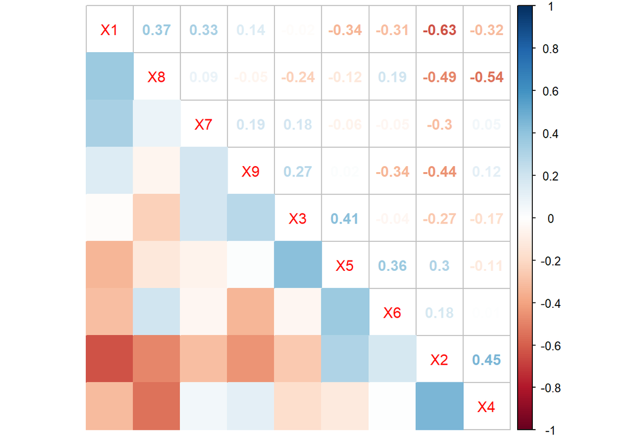

Jak widać na macierzy korelacji wartości korelacji pomiędzy poszczególnymi zmiennymi na ogół jest niewielka i w większości przypadków nie przekracza 0,4. Jest to jak najbardziej pożądane zjawisko i świadczy o tym ,iż dane zawierają unikatowe informacje. Co ciekawe największa ujemna korelacja wynosząca -0,63 występuje pomiędzy zmiennymi które wyrażaj ilość żłobków(X1) oraz ilość szkół podstawowych(X2) przypadających na 10000 mieszkańców.

## Współczynnik zmienności

```
## [1] "X1"
## [1] 0.4061013
## [1] "X2"
## [1] 0.3816614
## [1] "X3"
## [1] 0.4211208
## [1] "X4"
## [1] 0.4929723
## [1] "X5"
## [1] 0.8735504
## [1] "X6"
## [1] 0.7910604
## [1] "X7"
## [1] 0.1472013
## [1] "X8"
## [1] 1.0238
## [1] "X9"
## [1] 0.1858937
```

# Badanie empiryczne

### Metoda TOPSIS

|  | alt.row | score | rank |
| --- | --- | --- | --- |
| Powiat bełchatowski | 1 | 0.3945392 | 7 |
| Powiat kutnowski | 2 | 0.4157749 | 6 |
| Powiat łaski | 3 | 0.2220510 | 22 |
| Powiat łęczycki | 4 | 0.3470342 | 13 |
| Powiat łowicki | 5 | 0.3247015 | 16 |
| Powiat łódzki wschodni | 6 | 0.3561919 | 12 |
| Powiat opoczyński | 7 | 0.3899889 | 8 |
| Powiat pabianicki | 8 | 0.2621718 | 21 |
| Powiat pajęczański | 9 | 0.1955086 | 24 |
| Powiat piotrkowski | 10 | 0.2698656 | 20 |
| Powiat poddębicki | 11 | 0.3075937 | 18 |
| Powiat radomszczański | 12 | 0.3227528 | 17 |
| Powiat rawski | 13 | 0.3652674 | 10 |
| Powiat sieradzki | 14 | 0.3258942 | 15 |
| Powiat skierniewicki | 15 | 0.5052789 | 2 |
| Powiat tomaszowski | 16 | 0.3000151 | 19 |
| Powiat wieluński | 17 | 0.3577989 | 11 |
| Powiat wieruszowski | 18 | 0.3748288 | 9 |
| Powiat zduńskowolski | 19 | 0.3409630 | 14 |
| Powiat zgierski | 20 | 0.2207499 | 23 |
| Powiat brzeziński | 21 | 0.5381434 | 1 |
| Powiat m.Łódź | 22 | 0.4771313 | 3 |
| Powiat m.Piotrków Trybunalski | 23 | 0.4545365 | 4 |
| Powiat m.Skierniewice | 24 | 0.4263737 | 5 |

### Metoda standaryzowanych sum

|  | x |
| --- | --- |
| Powiat bełchatowski | 1.0000000 |
| Powiat skierniewicki | 0.9940323 |
| Powiat brzeziński | 0.7769795 |
| Powiat m.Łódź | 0.6868090 |
| Powiat rawski | 0.6845938 |
| Powiat opoczyński | 0.6541247 |
| Powiat łódzki wschodni | 0.5455670 |
| Powiat m.Piotrków Trybunalski | 0.5453056 |
| Powiat wieruszowski | 0.5227082 |
| Powiat poddębicki | 0.4979665 |
| Powiat kutnowski | 0.4940568 |
| Powiat zduńskowolski | 0.4767765 |
| Powiat m.Skierniewice | 0.4713329 |
| Powiat radomszczański | 0.4709990 |
| Powiat wieluński | 0.4497570 |
| Powiat łowicki | 0.4261387 |
| Powiat piotrkowski | 0.4164051 |
| Powiat łęczycki | 0.4068170 |
| Powiat sieradzki | 0.3841545 |
| Powiat pabianicki | 0.3146606 |
| Powiat zgierski | 0.2673856 |
| Powiat tomaszowski | 0.1914877 |
| Powiat łaski | 0.0316563 |
| Powiat pajęczański | 0.0000000 |

Metoda standaryzowanych sum dała następujące rezultaty:  
3 najlpesze powiaty to:  
-powiat bełchatowski  
-powiat skierniewicki  
-powait brzeziński  
3 najgorsze powaiaty to:  
-Powiat pajęczański  
-Powiat łaski  
-Powiat tomaszowski

### Hellwig

|  | x |
| --- | --- |
| Powiat bełchatowski | 0.3033321 |
| Powiat skierniewicki | 0.2356643 |
| Powiat rawski | 0.2140212 |
| Powiat m.Łódź | 0.2071791 |
| Powiat opoczyński | 0.1795027 |
| Powiat brzeziński | 0.1675121 |
| Powiat poddębicki | 0.1652716 |
| Powiat łódzki wschodni | 0.1645563 |
| Powiat łowicki | 0.1543839 |
| Powiat łęczycki | 0.1540918 |
| Powiat zduńskowolski | 0.1510082 |
| Powiat sieradzki | 0.1426875 |
| Powiat wieluński | 0.1408869 |
| Powiat radomszczański | 0.1298520 |
| Powiat kutnowski | 0.1232089 |
| Powiat piotrkowski | 0.1138117 |
| Powiat wieruszowski | 0.1089535 |
| Powiat pabianicki | 0.1011186 |
| Powiat m.Piotrków Trybunalski | 0.0935053 |
| Powiat zgierski | 0.0933538 |
| Powiat m.Skierniewice | 0.0819103 |
| Powiat tomaszowski | 0.0597466 |
| Powiat pajęczański | 0.0062875 |
| Powiat łaski | -0.0093853 |

Metoda Hellwiga dała następujące rezultaty:  
3 najlpesze powiaty to:  
-powiat bełchatowski  
-powiat skierniewicki  
-powait rawski  
3 najgorsze powaiaty to:  
-Powiat łaski  
-Powiat pajęczański  
-Powiat tomaszowski

Warto tu zwrócić uwage jak bardzo wynik powiatu bełchatowskiego rózni się od reszty powiatów. Różnica ta jest widoczna już w porównaniu z powiatem znajdującym się na drugiej pozycji, wartość dla powiatu skierniewickiego jest mniejsza o 22,3%.

# Interpretacja wyników oraz podsumowanie

Przeprowadzone badania pozwoliły wytypować powiaty które wydają się oferować najlepsze warunki do życia. Wszystkie trzy metody usytułowały powiat skierniewicki na drugiej pozycji biorąc pod uwage ,że badane były 24 powiaty jest to wysoka pozycja.Warto również wspomnieć o powiecie bełcahotwskim który wdlug dwóch metod jest najlepszy.

Mapa przedstawia klasywikacje za pomocą metody standaryzowanych sum, na czerwono najlepsze, żółto dobre , cimno zielone średnie oraz na jasno zielone powiaty z najgorszymi warunakmi do życia.

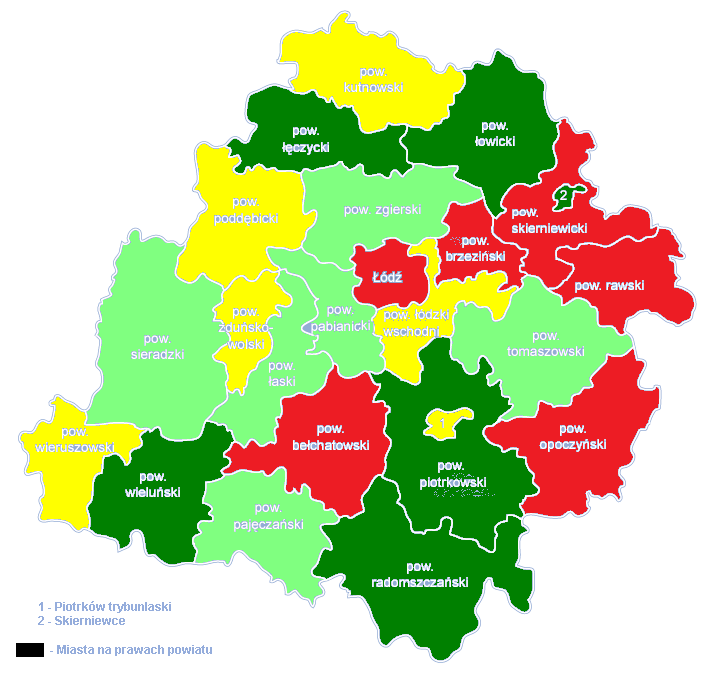

## Przegląd postawionych hipotez

### Miasta na prawach powiatu będą w czałówce rankingu ze względu na większe wydatki na mieszkańców oraz bardziej rozwiniętą infrastrukture.

Najwyższe miejsca miast na prawach powiatu uzyskano przy użyciu metody TOPSIS. Wszystkie trzy znajdują się w pierwszej piątce co świadczyło by o prawdziwości tej hipotezy, jeśli pod uwagę nie były brane inne metody. Pozostałe dwie metody nie dały już aż tak oczekiwanych wyników, zwłaszcza metoda Hellwiga która umieściła Powiat m.Piotrków Trybunalski oraz Powiat m.Skierniewice na 19 i 21 miejscu. Co ciekawe mimo tak róźnych wyników dla wspomnianych wcześniej dwóch powiatów Powiat m.Łódź w porządkowaniu przy pomocy każdej metody wypada dobrze, zapewne przyczyną tego jest rozmiar miasta Powiatu m.Łódź, dużej liczby ludności oraz zakresu wygód jakie oferuje tak duże miasto.

### W czołówce będzie znajdować sie powiat bełchatowski ze względu na fakt, iż w jego skład wchodzi gmina kleszczów, która jest najbogatszą gminą w Polsce, a także na industrialny charakter tego regionu(kopalnia węgla brunatnego oraz elektrowania).

Powiat bełchatowski uklasował się na pierwszym miejscu przy użyciu dwóch metod Hellwiga oraz standaryzowanych sum w analizie za pomocą metody TOPSIS był na 7 miejscu czyli również nienisko, niewątpliwe świadczy to o wyskoiej jakości życia w tym regionie. Kopalnia węgla bruntnego oraz elektorwania tworzą wiele miejsc pracy z dobrym wynagrodzeniem. Powód dla którego powiat bełchatowski znajduje się wysoko to oczywiście miasto Bełchatów które oferuj wygody takie jak ośrodki rozwoju kultury ale takze wpływa na podnisienie wydatków budżetów powiatowych na mieskzańca w tym regionie co może świadczyć o wyższej jakości życia na tym obszarze.Przedsatwione argumenty wydają się potwierdzać prawdziwość hipotezy.

### Powiaty w których znajdują się miasta będą znajdować się w czołówce.

Niewątpliwie powiaty w których znajdują się miasta klasują się na ogół wyżej w rankingach wyznaczonych przy pomocy wybranych metod porządkowania liniowego. Nasuwają się zatem wnioski, że obecność miast w powiecie determinuje poprawę czynników wpływających na jakość życia oraz ,iż nasz hipoteza jest prawdziwa.